# Analytics Workflow

Andreas Van Dijck

9/23/2020

## Overview

This file is part of my business value proposition. My propisition consists of developing a linear regression model to show what factors constitute a wine with a high expert rating. The full datasets were obtained from http://www3.dsi.uminho.pt/pcortez/wine/.

## Data Description

Color (R=Red, W=White). Qualitative, nominal variable or a factor with two levels.

Fixed acidity: measures the amount of acids in the wine (grams per liter) that do not evaporate. Quantitative, continuous variable. Numeric in R.

Volatile acidity: amount of acetic acid in wine (grams per liter) that can evaporate. Quantitative, continuous variable. Numeric in R.

Residual sugar: measures the amount of sugar in the wine (grams per liter). Quantitative, continuous variable. Numeric in R.

Chlorides: amount of salt in the wine (grams per liter). Quantitative, continuous variable. Numeric in R. Free sulfur dioxide: the amount of Sulfur dioxide in wine at the molecular level (as a dissolved gas), measured in milligrams per liter. Quantitative, continuous variable. Numeric in R.

Total sulfur dioxide: all forms of sulfur dioxide in wine in milligrams per liter. Quantitative, continuous variable. Numeric in R.

Density: the liquid’s weight in grams per milliliter. Quantitative, continuous variable. Numeric in R.

pH: describes how acidic or basic a wine is on a scale from 0 (very acidic) to 14 (very basic). Quantitative, continuous variable. Numeric in R.

Sulphates: the amount of sulphates in the wine measured in grams per liter. Quantitative, continuous variable. Numeric in R.

Alcohol: the wine’s percentage alcohol content. Quantitative, continuous variable. Numeric in R.

Quality: an expert rating between 0 and 10 based on sensory data describing the overall quality of the wine. Quantitative, discrete variable. Integer in R.

## Data Preprocessing

To preprocess the data, I combined the spreadsheets for white wines and red wines into one spreadsheet so that all of the wine data is in one place. I also looked at the data to make sure everything was in the right place.

The first step is to load the data into R as follows, and then check the class objects to make sure everything is coded correctly:

```r
wine<-read.csv("winequalityN.csv")
str(wine)
```

```
## 'data.frame':    6497 obs. of  13 variables:
##  $ type                : Factor w/ 2 levels "red","white": 2 2 2 2 2 2 2 2 2 2 ...
##  $ fixed.acidity       : num  7 6.3 8.1 7.2 7.2 8.1 6.2 7 6.3 8.1 ...
##  $ volatile.acidity    : num  0.27 0.3 0.28 0.23 0.23 0.28 0.32 0.27 0.3 0.22 ...
##  $ citric.acid         : num  0.36 0.34 0.4 0.32 0.32 0.4 0.16 0.36 0.34 0.43 ...
##  $ residual.sugar      : num  20.7 1.6 6.9 8.5 8.5 6.9 7 20.7 1.6 1.5 ...
##  $ chlorides           : num  0.045 0.049 0.05 0.058 0.058 0.05 0.045 0.045 0.049 0.044 ...
##  $ free.sulfur.dioxide : num  45 14 30 47 47 30 30 45 14 28 ...
##  $ total.sulfur.dioxide: num  170 132 97 186 186 97 136 170 132 129 ...
##  $ density             : num  1.001 0.994 0.995 0.996 0.996 ...
##  $ pH                  : num  3 3.3 3.26 3.19 3.19 3.26 3.18 3 3.3 3.22 ...
##  $ sulphates           : num  0.45 0.49 0.44 0.4 0.4 0.44 0.47 0.45 0.49 0.45 ...
##  $ alcohol             : num  8.8 9.5 10.1 9.9 9.9 10.1 9.6 8.8 9.5 11 ...
##  $ quality             : int  6 6 6 6 6 6 6 6 6 6 ...
```

## Check Target Variable

To understand the nature of the target variable, wine quality, I construct a histogram to check its distribution. According to the output below, wine quality appears to be roughly normally distributed.

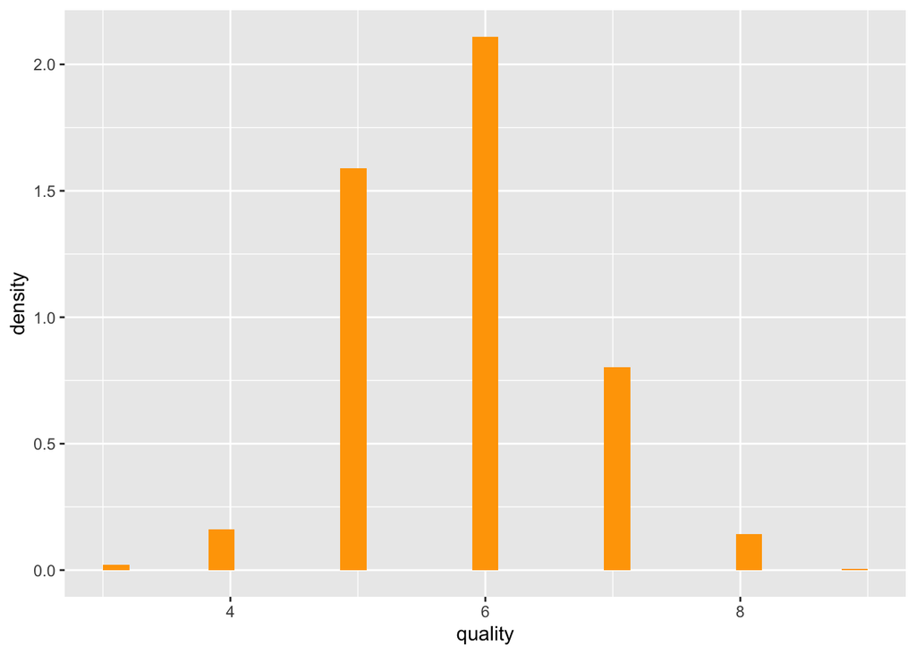

```r
library(ggplot2)
# Building histogram
ggplot(data=wine, aes(quality)) +
  geom_histogram(aes(y =..density..), fill = "orange")
```

## Getting a quick summary

Using the skimr package, I can get a quick summary of each variable and check for missing observations.

```r
library(skimr)
skim(wine)
```

Data summary

| Name | wine |
| --- | --- |
| Number of rows | 6497 |
| Number of columns | 13 |
| _______________________ |  |
| Column type frequency: |  |
| factor | 1 |
| numeric | 12 |
| ________________________ |  |
| Group variables | None |

**Variable type: factor**

| skim_variable | n_missing | complete_rate | ordered | n_unique | top_counts |
| --- | --- | --- | --- | --- | --- |
| type | 0 | 1 | FALSE | 2 | whi: 4898, red: 1599 |

**Variable type: numeric**

| skim_variable | n_missing | complete_rate | mean | sd | p0 | p25 | p50 | p75 | p100 | hist |
| --- | --- | --- | --- | --- | --- | --- | --- | --- | --- | --- |
| fixed.acidity | 10 | 1 | 7.22 | 1.30 | 3.80 | 6.40 | 7.00 | 7.70 | 15.90 | ▂▇▁▁▁ |
| volatile.acidity | 8 | 1 | 0.34 | 0.16 | 0.08 | 0.23 | 0.29 | 0.40 | 1.58 | ▇▂▁▁▁ |
| citric.acid | 3 | 1 | 0.32 | 0.15 | 0.00 | 0.25 | 0.31 | 0.39 | 1.66 | ▇▅▁▁▁ |
| residual.sugar | 2 | 1 | 5.44 | 4.76 | 0.60 | 1.80 | 3.00 | 8.10 | 65.80 | ▇▁▁▁▁ |
| chlorides | 2 | 1 | 0.06 | 0.04 | 0.01 | 0.04 | 0.05 | 0.06 | 0.61 | ▇▁▁▁▁ |
| free.sulfur.dioxide | 0 | 1 | 30.53 | 17.75 | 1.00 | 17.00 | 29.00 | 41.00 | 289.00 | ▇▁▁▁▁ |
| total.sulfur.dioxide | 0 | 1 | 115.74 | 56.52 | 6.00 | 77.00 | 118.00 | 156.00 | 440.00 | ▅▇▂▁▁ |
| density | 0 | 1 | 0.99 | 0.00 | 0.99 | 0.99 | 0.99 | 1.00 | 1.04 | ▇▂▁▁▁ |
| pH | 9 | 1 | 3.22 | 0.16 | 2.72 | 3.11 | 3.21 | 3.32 | 4.01 | ▁▇▆▁▁ |
| sulphates | 4 | 1 | 0.53 | 0.15 | 0.22 | 0.43 | 0.51 | 0.60 | 2.00 | ▇▃▁▁▁ |
| alcohol | 0 | 1 | 10.49 | 1.19 | 8.00 | 9.50 | 10.30 | 11.30 | 14.90 | ▃▇▅▂▁ |
| quality | 0 | 1 | 5.82 | 0.87 | 3.00 | 5.00 | 6.00 | 6.00 | 9.00 | ▁▆▇▃▁ |

## Remove missing values

After checking for missing values, I perform a simple function to remove these values from the dataset, and check the dimensions to make sure the dataset is still sound.

```r
wine_clean<-na.omit(wine)
dim(wine_clean)
```

```
## [1] 6463   13
```

Dropping missing observations did not change the total number of rows by much, so there is no need for imputation.

## Split the data into testing and validation sets

```r
library(caret) #this package has the createDataPartition function
 set.seed(123) #randomization so that results are reproducible

 #creating indices
 trainIndex <- createDataPartition(wine_clean$quality,p=0.75,list=FALSE)

 #splitting data into training/testing data using the trainIndex object
 wine_train <- wine_clean[trainIndex,] #training data (75% of data)

 wine_test <- wine_clean[-trainIndex,] #testing data (25% of data)
```

## Ininitialize an algorithim to fit a linear regression model

To start the process of deciding what variables to include in the model, I first build a full model with all the variables.

```r
full<-lm(quality~.,data=wine_train)
options(scipen = 999) #Gets numbers out of scientific notation
summary(full)
```

```
##
## Call:
## lm(formula = quality ~ ., data = wine_train)
##
## Residuals:
##     Min      1Q  Median      3Q     Max
## -3.4039 -0.4659 -0.0435  0.4613  3.0233
##
## Coefficients:
##                          Estimate   Std. Error t value             Pr(>|t|)
## (Intercept)           112.8790641   18.0314069   6.260       0.000000000418 ***
## typewhite              -0.3783255    0.0679722  -5.566       0.000000027490 ***
## fixed.acidity           0.0855904    0.0193176   4.431       0.000009600885 ***
## volatile.acidity       -1.5564601    0.0927766 -16.776 < 0.0000000000000002 ***
## citric.acid            -0.0717285    0.0923065  -0.777             0.437156
## residual.sugar          0.0654881    0.0072213   9.069 < 0.0000000000000002 ***
## chlorides              -0.8861353    0.3773010  -2.349             0.018883 *
## free.sulfur.dioxide     0.0032942    0.0008648   3.809             0.000141 ***
## total.sulfur.dioxide   -0.0013125    0.0003709  -3.539             0.000406 ***
## density              -112.0083100   18.2714099  -6.130       0.000000000947 ***
## pH                      0.5291259    0.1067390   4.957       0.000000739638 ***
## sulphates               0.7978814    0.0889563   8.969 < 0.0000000000000002 ***
## alcohol                 0.2085638    0.0227986   9.148 < 0.0000000000000002 ***
## ---
## Signif. codes:  0 '***' 0.001 '**' 0.01 '*' 0.05 '.' 0.1 ' ' 1
##
## Residual standard error: 0.7288 on 4835 degrees of freedom
## Multiple R-squared:  0.299,  Adjusted R-squared:  0.2972
## F-statistic: 171.8 on 12 and 4835 DF,  p-value: < 0.00000000000000022
```

Next, I perfrom a stepwise regression using AIC as the selection criteria.

```r
null<-lm(quality~1, data=wine_train)
lm.step<-step(null, scope=list(lower=null, upper=full), direction="both", trace=0)#trace=0 suppresses output.  Change trace=1 or 2 to get more
summary(lm.step)
```

```
##
## Call:
## lm(formula = quality ~ alcohol + volatile.acidity + sulphates +
##     residual.sugar + type + density + chlorides + pH + fixed.acidity +
##     free.sulfur.dioxide + total.sulfur.dioxide, data = wine_train)
##
## Residuals:
##     Min      1Q  Median      3Q     Max
## -3.3936 -0.4668 -0.0423  0.4614  3.0218
##
## Coefficients:
##                          Estimate   Std. Error t value             Pr(>|t|)
## (Intercept)           113.7149060   17.9985583   6.318       0.000000000289 ***
## alcohol                 0.2066110    0.0226587   9.118 < 0.0000000000000002 ***
## volatile.acidity       -1.5330956    0.0877657 -17.468 < 0.0000000000000002 ***
## sulphates               0.7937349    0.0887925   8.939 < 0.0000000000000002 ***
## residual.sugar          0.0656754    0.0072170   9.100 < 0.0000000000000002 ***
## typewhite              -0.3838896    0.0675912  -5.680       0.000000014292 ***
## density              -112.8512532   18.2384328  -6.188       0.000000000661 ***
## chlorides              -0.9379190    0.3713542  -2.526             0.011579 *
## pH                      0.5364299    0.1063200   5.045       0.000000469082 ***
## fixed.acidity           0.0827843    0.0189763   4.363       0.000013125904 ***
## free.sulfur.dioxide     0.0032925    0.0008648   3.807             0.000142 ***
## total.sulfur.dioxide   -0.0013348    0.0003697  -3.610             0.000309 ***
## ---
## Signif. codes:  0 '***' 0.001 '**' 0.01 '*' 0.05 '.' 0.1 ' ' 1
##
## Residual standard error: 0.7287 on 4836 degrees of freedom
## Multiple R-squared:  0.2989, Adjusted R-squared:  0.2973
## F-statistic: 187.4 on 11 and 4836 DF,  p-value: < 0.00000000000000022
```

## Compare the full and reduced models

```r
library(forecast) #This package can calculate RMSE to compare the performances of the models
p.full<-predict(full, newdata=wine_test) #Get predicted values on test data
p.step<-predict(lm.step, newdata=wine_test)
head(p.full)
```

```
##        6        9       13       17       42       43
## 5.831642 5.265039 6.193144 5.092122 5.280173 5.478474
```

```r
head(p.step)
```

```
##        6        9       13       17       42       43
## 5.834359 5.269460 6.191774 5.080918 5.278444 5.471944
```

After taking a look at the predicted values for the test data, I use accuracy() to get the RMSE

```r
accuracy(p.full, wine_test$quality)
```

```
##                   ME      RMSE       MAE       MPE     MAPE
## Test set 0.007714376 0.7454434 0.5773772 -1.608029 10.29381
```

```r
accuracy(p.step, wine_test$quality)
```

```
##                   ME     RMSE       MAE       MPE     MAPE
## Test set 0.007657905 0.745524 0.5771954 -1.608536 10.28935
```

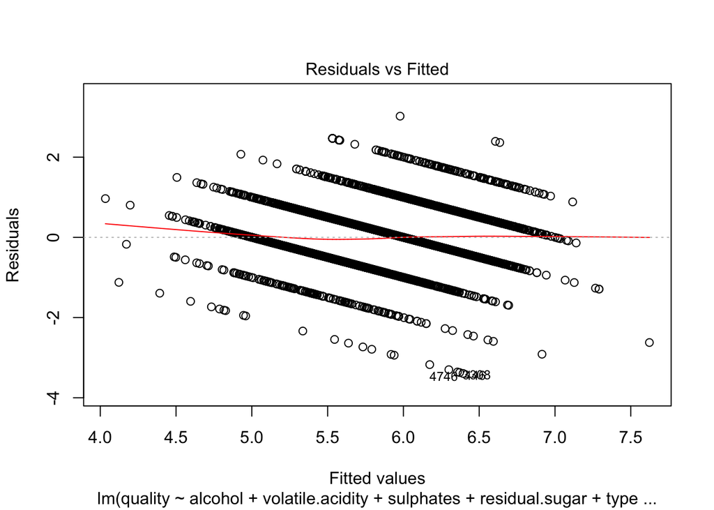

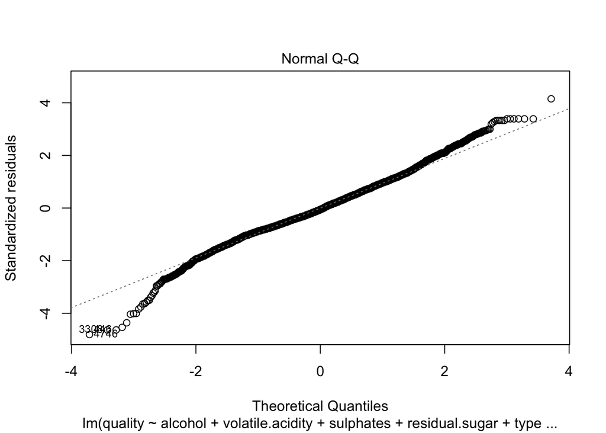

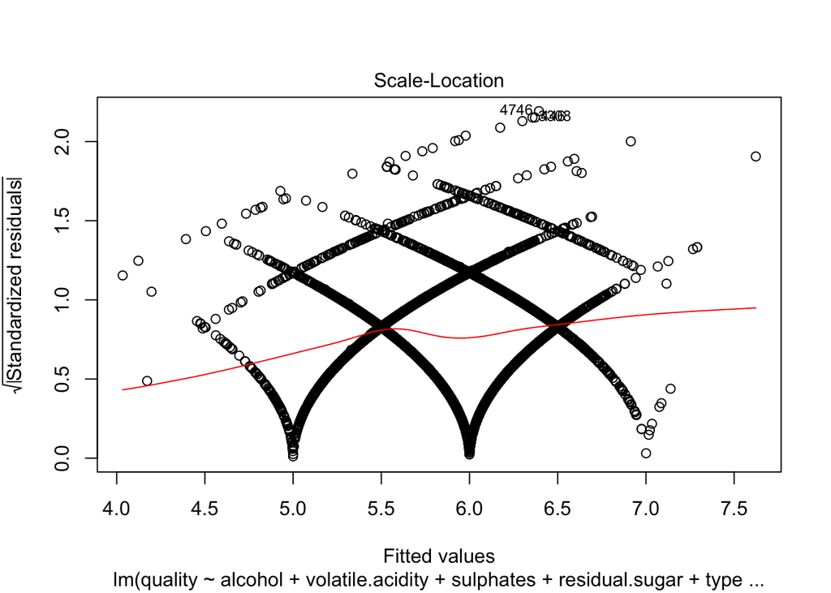

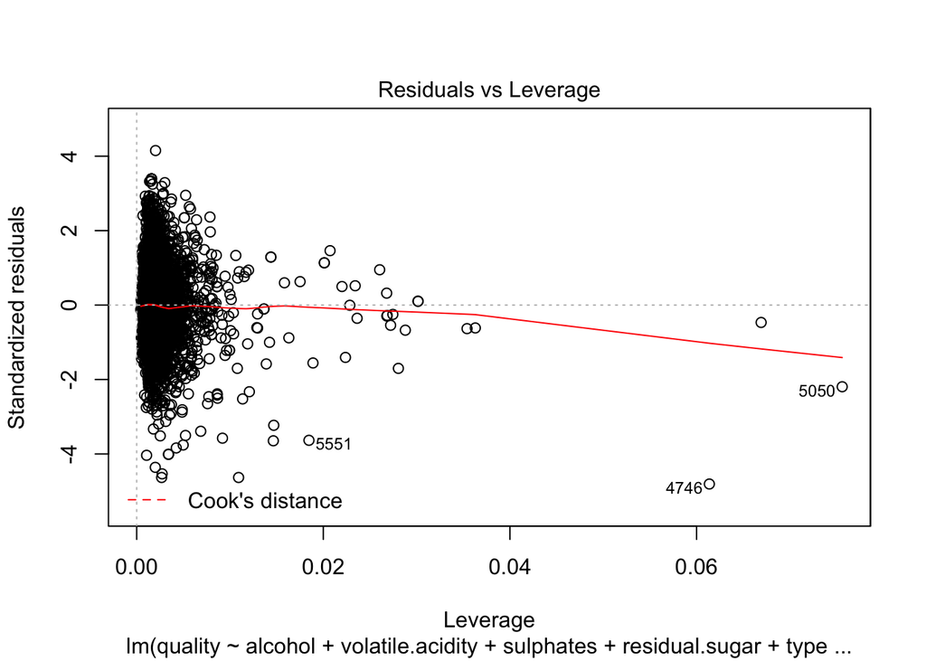

```r
plot(lm.step)
```

The residuals vs fitted values plot and the normal-qq plot help us evaluate the model by seeing how the residuals are distributed.

## Conclusion

In conclusion, this model is what I am offering as a business value proposition to negate the need for money and time being spent on taste testing, which is subject to human error and bias. This model would therefore save a client(e.g. a buyer for a wine company) time and money, and help them more easily identify what "good" wines are.

The final regression equation (with the slope coefficients rounded very slightly) is as follows:

lm(formula = quality ~ .21(alcohol) -1.53(volatile.acidity) + .8(sulphates) + .066(residual.sugar) -.38(type) -112.85(density) -.94(chlorides) + .54(pH) + .083(fixed.acidity) + .003(free.sulfur.dioxide) -.001(total.sulfur.dioxide)